# Feature Selection3

Muhammet Fatih ANAÇ

2024-08-08

## Veri Setinin Yüklenmesi

```r
file_path <- file.choose()
veri <- read.csv(file_path)
head(veri)
```

```
##      CRIM ZN INDUS CHAS   NOX    RM  AGE    DIS RAD TAX PTRATIO      B LSTAT
## 1 0.00632 18  2.31    0 0.538 6.575 65.2 4.0900   1 296    15.3 396.90  4.98
## 2 0.02731  0  7.07    0 0.469 6.421 78.9 4.9671   2 242    17.8 396.90  9.14
## 3 0.02729  0  7.07    0 0.469 7.185 61.1 4.9671   2 242    17.8 392.83  4.03
## 4 0.03237  0  2.18    0 0.458 6.998 45.8 6.0622   3 222    18.7 394.63  2.94
## 5 0.06905  0  2.18    0 0.458 7.147 54.2 6.0622   3 222    18.7 396.90  5.33
## 6 0.02985  0  2.18    0 0.458 6.430 58.7 6.0622   3 222    18.7 394.12  5.21
##   MEDV
## 1 24.0
## 2 21.6
## 3 34.7
## 4 33.4
## 5 36.2
## 6 28.7
```

```r
summary(veri)
```

```
##       CRIM                ZN             INDUS            CHAS
##  Min.   : 0.00632   Min.   :  0.00   Min.   : 0.46   Min.   :0.00000
##  1st Qu.: 0.08205   1st Qu.:  0.00   1st Qu.: 5.19   1st Qu.:0.00000
##  Median : 0.25651   Median :  0.00   Median : 9.69   Median :0.00000
##  Mean   : 3.61352   Mean   : 11.36   Mean   :11.14   Mean   :0.06917
##  3rd Qu.: 3.67708   3rd Qu.: 12.50   3rd Qu.:18.10   3rd Qu.:0.00000
##  Max.   :88.97620   Max.   :100.00   Max.   :27.74   Max.   :1.00000
##       NOX               RM             AGE              DIS
##  Min.   :0.3850   Min.   :3.561   Min.   :  2.90   Min.   : 1.130
##  1st Qu.:0.4490   1st Qu.:5.886   1st Qu.: 45.02   1st Qu.: 2.100
##  Median :0.5380   Median :6.208   Median : 77.50   Median : 3.207
##  Mean   :0.5547   Mean   :6.285   Mean   : 68.57   Mean   : 3.795
##  3rd Qu.:0.6240   3rd Qu.:6.623   3rd Qu.: 94.08   3rd Qu.: 5.188
##  Max.   :0.8710   Max.   :8.780   Max.   :100.00   Max.   :12.127
##       RAD              TAX           PTRATIO            B
##  Min.   : 1.000   Min.   :187.0   Min.   :12.60   Min.   :  0.32
##  1st Qu.: 4.000   1st Qu.:279.0   1st Qu.:17.40   1st Qu.:375.38
##  Median : 5.000   Median :330.0   Median :19.05   Median :391.44
##  Mean   : 9.549   Mean   :408.2   Mean   :18.46   Mean   :356.67
##  3rd Qu.:24.000   3rd Qu.:666.0   3rd Qu.:20.20   3rd Qu.:396.23
##  Max.   :24.000   Max.   :711.0   Max.   :22.00   Max.   :396.90
##      LSTAT            MEDV
##  Min.   : 1.73   Min.   : 5.00
##  1st Qu.: 6.95   1st Qu.:17.02
##  Median :11.36   Median :21.20
##  Mean   :12.65   Mean   :22.53
##  3rd Qu.:16.95   3rd Qu.:25.00
##  Max.   :37.97   Max.   :50.00
```

#### CHAS ve RAD değişkenlerinin kategorik olduğu anlaşılıyor.

## Eksik Gözlem Kontrolü

```
##  /\     /\
## {  `---'  }
## {  O   O  }
## ==>  V <==  No need for mice. This data set is completely observed.
##  \  \|/  /
##   `-----'
```

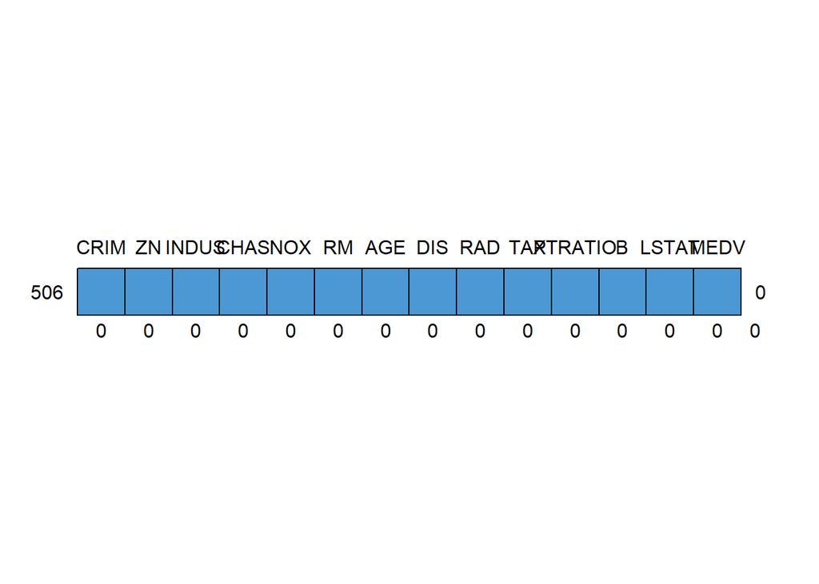

```
##     CRIM ZN INDUS CHAS NOX RM AGE DIS RAD TAX PTRATIO B LSTAT MEDV
## 506    1  1     1    1   1  1   1   1   1   1       1 1     1    1 0
##        0  0     0    0   0  0   0   0   0   0       0 0     0    0 0
```

```r
library(mice)
md.pattern(veri)
```

#### Veride eksik gözlem yok.

#### Ridge, Lasso, Elasticnet ve Pearson Korelasyon özellik seçimi yöntemlerini uygulayabilmek için veri setindeki tüm değişkenlerin sayısal değişken olması gerekiyor. Bu yüzden CHAS ve RAD değişkenlerinin veri setinden çıkarılması gerekiyor.

```r
veri<-veri[ ,-c(4,9)]
colnames(veri)
```

```
##  [1] "CRIM"    "ZN"      "INDUS"   "NOX"     "RM"      "AGE"     "DIS"
##  [8] "TAX"     "PTRATIO" "B"       "LSTAT"   "MEDV"
```

## Veriyi Eğitim ve Test Verisi Olarak Ayırma

```r
set.seed(123)
n<-nrow(veri)
index<-sample(1:n, round(0.75*n))

train<-veri[index,]
test<-veri[-index, ]

xtrain<-train[,-12]
xtrain<-as.matrix(xtrain)
ytrain<-train[,12]

xtest<-test[,-12]
xtest<-as.matrix(xtest)
ytest<-test[,12]
```

## Lineer Regresyon Modeli

```r
lineer_model<-lm(MEDV~., data=train)
summary(lineer_model)
```

```
##
## Call:
## lm(formula = MEDV ~ ., data = train)
##
## Residuals:
##      Min       1Q   Median       3Q      Max
## -11.8925  -2.9160  -0.6114   1.5663  26.3961
##
## Coefficients:
##               Estimate Std. Error t value Pr(>|t|)
## (Intercept)  3.289e+01  5.866e+00   5.606 4.07e-08 ***
## CRIM        -6.806e-02  3.473e-02  -1.959  0.05081 .
## ZN           4.968e-02  1.633e-02   3.043  0.00251 **
## INDUS       -6.797e-02  7.319e-02  -0.929  0.35367
## NOX         -1.261e+01  4.539e+00  -2.778  0.00574 **
## RM           3.701e+00  4.936e-01   7.497 4.93e-13 ***
## AGE         -9.815e-04  1.590e-02  -0.062  0.95082
## DIS         -1.619e+00  2.384e-01  -6.790 4.50e-11 ***
## TAX          1.522e-03  2.862e-03   0.532  0.59522
## PTRATIO     -8.313e-01  1.546e-01  -5.376 1.35e-07 ***
## B            6.455e-03  3.453e-03   1.869  0.06238 .
## LSTAT       -6.031e-01  5.962e-02 -10.116  < 2e-16 ***
## ---
## Signif. codes:  0 '***' 0.001 '**' 0.01 '*' 0.05 '.' 0.1 ' ' 1
##
## Residual standard error: 4.925 on 368 degrees of freedom
## Multiple R-squared:  0.7243, Adjusted R-squared:  0.7161
## F-statistic: 87.91 on 11 and 368 DF,  p-value: < 2.2e-16
```

#### INDUS, AGE, TAX değişkenlerinin bağımlı değişken üzerinde çok az etkiye sahip olduğu Estimate değerlerinden anlaşılıyor. Bu değişkenlerin pvalue değerlerinden; INDUS, AGE, TAX değişkenlerinin bağımlı değişken üzerindeki etkilerinin anlamsız olduğu anlaşılıyor.

#### R2 değeri 0.716 olarak hesaplanmış. Bunun anlamı, bağımlı değişken olan MEDV değişkenindeki değişimin %71’i bağımsız değişkenlerdeki değişim ile açıklanabilmiştir. Modelin p-value değerine göre model anlamlıdır.

## Katsayıların İncelenmesi

```r
coef(lineer_model)
```

```
##   (Intercept)          CRIM            ZN         INDUS           NOX
##  3.288548e+01 -6.805931e-02  4.968330e-02 -6.797023e-02 -1.261110e+01
##            RM           AGE           DIS           TAX       PTRATIO
##  3.700735e+00 -9.814807e-04 -1.619078e+00  1.521950e-03 -8.313282e-01
##             B         LSTAT
##  6.455084e-03 -6.031347e-01
```

#### Anlamlı olan değişkenlerin katsayılarına göre, NOX değişkenindeki 1 birimlik artış MEDV değişkeninde 12 birimlik azalışa sebep oluyor. RM değişkenindeki 1 birimlik artış MEDV değişkeninde 3.7 birimlik artışa sebep oluyor. Verisetine göre ev fiyatlarındaki değişimde en çok etkisi olan iki kriter, evin bulunduğu bölgedeki hava kirliliği ve evin oda sayısıdır. Hava kirliliğinin artması ev fiyatını düşürürken oda sayısının artması ev fiyatını yüksetmektedir.

#### Diğer anlamlı değişkenlerin katsayıları da benzer şekilde yorumlanabilir.

## Normallik

```r
library(olsrr)
n<-nrow(train)
n
```

```
## [1] 380
```

```r
ols_test_normality(lineer_model)
```

```
## -----------------------------------------------
##        Test             Statistic       pvalue
## -----------------------------------------------
## Shapiro-Wilk              0.8753         0.0000
## Kolmogorov-Smirnov        0.1317         0.0000
## Cramer-von Mises         32.6615         0.0000
## Anderson-Darling         10.0091         0.0000
## -----------------------------------------------
```

#### n=380>50 olduğu için Kolmogrov sonucuna bakılması gerekiyor. p<0.05 olduğu için “H0: Artıklar normal dağılmaktadır” hipotezi reddedilir. Bu durumu grafik üzerinden kontrol etmek istersek:

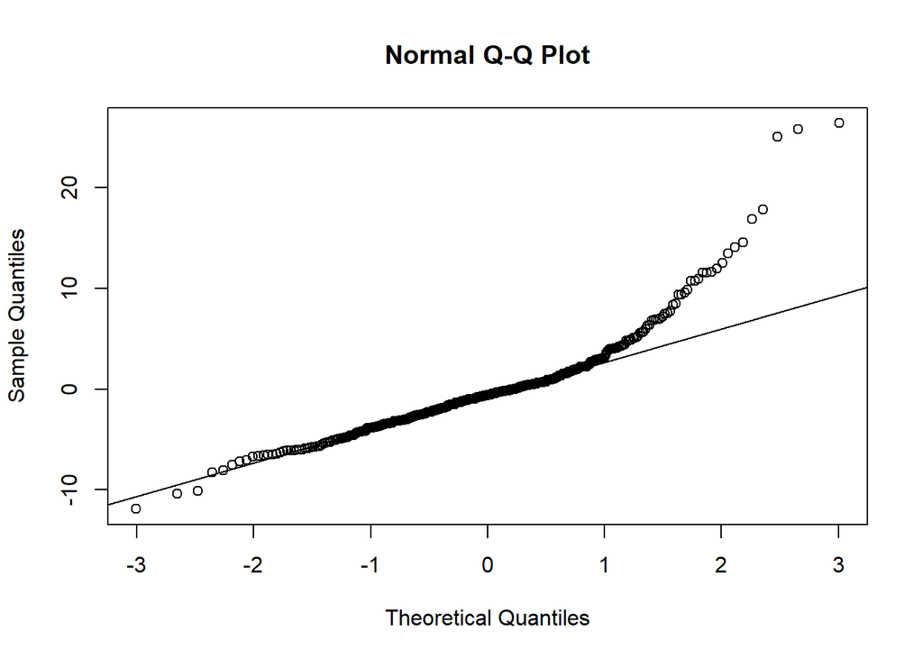

```r
qqnorm(residuals(lineer_model))
qqline(residuals(lineer_model))
```

#### Grafik, test sonucunu doğruluyor. Artıklar normal dağılmamaktadır.

## Değişken Varyanslılık

```r
library(lmtest)
bptest(lineer_model)
```

```
##
##  studentized Breusch-Pagan test
##
## data:  lineer_model
## BP = 41.277, df = 11, p-value = 2.159e-05
```

#### p<0.05 olduğu için “H0: Değişken varyanslılık problemi yoktur” hipotezi reddedilir. Değişken varyans problemi vardır.

## Aykırı Değer

```r
library(olsrr)
ols_test_outlier(lineer_model)
```

```
##     studentized_residual unadjusted_p_val bonferroni_p_val
## 372             5.342750     1.610355e-07     6.119348e-05
## 373             5.652747     3.176019e-08     1.206887e-05
## 369             5.679459     2.752127e-08     1.045808e-05
```

#### unadjusted_p_value değerine ve bonferroni_p_value değerine göre verisetinde 3 tane outlier vardır.

## Multicolinearity

```r
library(car)
vifs<-vif(lineer_model)
which(vifs>10)
```

```
## named integer(0)
```

#### 10’dan büyük vif değeri olmadığı için multicolinearity problemi yoktur.

#### Normallik, Değişken Varyans, Outlier varsayımları sağlanmıyor, Multicolinearity varsayımı sağlanıyor.

## Tahminlerin Elde Edilmesi

```r
set.seed(123)
tahmin<-predict(lineer_model, test)
```

## R2

```r
library(caret)
R2_lineer<-R2(tahmin, test$MEDV)
R2_lineer
```

```
## [1] 0.7077899
```

#### Model bağımlı değişkendeki toplam değişimin %70.77’sini bağımsız değişkenlerdeki değişimle açıklayabilmiştir.

## RMSE

```r
RMSE_lineer<-RMSE(tahmin, test$MEDV)
RMSE_lineer
```

```
## [1] 4.906913
```

## MAE

```r
MAE_lineer<-MAE(tahmin, test$MEDV)
MAE_lineer
```

```
## [1] 3.671364
```

#### Tahminler gerçek değerlere yakındır.

## RİDGE

```r
library(glmnet)
set.seed(123)
lambdas<-10^seq(3,-3,length=100)

cv_ridge<-cv.glmnet(xtrain, ytrain, alpha=0, lambda = lambdas)
opt_lambda<-cv_ridge$lambda.min
```

## Optimum Lambda Değeri İle Modelin Kurulması

```r
ridge_model<-glmnet(xtrain, ytrain, alpha = 0, lambda=opt_lambda)
```

## Katsayıların Değerlendirilmesi

```r
coef(ridge_model)
```

```
## 12 x 1 sparse Matrix of class "dgCMatrix"
##                        s0
## (Intercept)  3.051885e+01
## CRIM        -6.601487e-02
## ZN           4.445758e-02
## INDUS       -6.253878e-02
## NOX         -1.100261e+01
## RM           3.785102e+00
## AGE         -1.694831e-03
## DIS         -1.451683e+00
## TAX          9.363622e-04
## PTRATIO     -8.220492e-01
## B            6.658961e-03
## LSTAT       -5.755605e-01
```

## Tahminlerin Elde Edilmesi

```r
set.seed(123)
tahmin_test_ridge<-predict(ridge_model, s=opt_lambda, newx=xtest)
tahmin_test_ridge<-as.numeric(tahmin_test_ridge)
```

## R2

```r
library(caret)
R2_Ridge<-R2(tahmin_test_ridge, test$MEDV)
R2_Ridge
```

```
## [1] 0.7124708
```

#### Model bağımlı değişkendeki toplam değişimin %71.25’ini bağımsız değişkenlerdeki değişimle açıklayabilmiştir.

## RMSE

```r
RMSE_Ridge<-RMSE(tahmin_test_ridge, test$MEDV)
RMSE_Ridge
```

```
## [1] 4.869217
```

#### RMSE değeri sabit kalmış.

## MAE

```r
MAE_Ridge<-MAE(tahmin_test_ridge, test$MEDV)
MAE_Ridge
```

```
## [1] 3.626856
```

#### MAE değeri sabit kalmış.

## LASSO

```r
set.seed(123)
lambdas_lasso<-10^seq(3,-3,length=100)

cv_lasso<-cv.glmnet(xtrain, ytrain,alpha=1,lambda = lambdas_lasso)
optlambda_lasso<-cv_lasso$lambda.min
```

## Optimum Lambda Değeri İle Modelin Kurulması

```r
lasso_model <- glmnet(xtrain, ytrain, lambda = optlambda_lasso, alpha=1)
```

## Katsayıların Değerlendirilmesi

```r
coef(lasso_model)
```

```
## 12 x 1 sparse Matrix of class "dgCMatrix"
##                        s0
## (Intercept)  30.827437976
## CRIM         -0.056773353
## ZN            0.045361619
## INDUS        -0.041234987
## NOX         -10.747202068
## RM            3.741652925
## AGE           .
## DIS          -1.449887168
## TAX           .
## PTRATIO      -0.800520778
## B             0.005918181
## LSTAT        -0.601834669
```

#### NOX değişkeninin katsayısına göre, hava kirliliğinin yükselmesi o bölgedeki ev fiyatlarını olumsuz etkiler. NOX değişkenindeki 1 birimlik artış MEDV değişkeninde 11 birimlik azalışa sebep olur.

#### RM değişkeninin katsayısına göre, oda sayısının artması evlerin fiyatlarının yükselmesine sebep olur. RM değişkenindeki 1 birimlik artış MEDV değişkeninde 3.7 birimlik artışa sebep olur.

#### Diğer değişkenlerin katsayıları da benzer şekilde yorumlanabilir.

## Tahminlerin Elde Edilmesi

```r
set.seed(123)
tahmin_test_lasso<-predict(lasso_model, s=optlambda_lasso, newx=xtest)
tahmin_test_lasso<-as.numeric(tahmin_test_lasso)
```

## R2

```r
library(caret)
R2_Lasso<-R2(tahmin_test_lasso, test$MEDV)
R2_Lasso
```

```
## [1] 0.7090676
```

## RMSE

```r
RMSE_Lasso<-RMSE(tahmin_test_lasso, test$MEDV)
RMSE_Lasso
```

```
## [1] 4.89669
```

#### RMSE değeri sabit kalmış.

## MAE

```r
MAE_Lasso<-MAE(tahmin_test_lasso, test$MEDV)
MAE_Lasso
```

```
## [1] 3.655581
```

#### MAE değeri sabit kalmış.

## ELASTİCNET

```r
set.seed(123)
lambdas_elasticnet<-10^seq(3,-3,length=100)

cv_elasticnet<-cv.glmnet(xtrain, ytrain,alpha=0.5,lambda = lambdas_elasticnet)
opt_lambda_elastic<-cv_elasticnet$lambda.min
```

## Optimum Lambda Değeri İle Modelin Kurulması

```r
elasticnet_model<-glmnet(xtrain, ytrain, alpha = 0.5, lambda=opt_lambda_elastic)
```

## Katsayıların Değerlendirilmesi

```r
coef(elasticnet_model)
```

```
## 12 x 1 sparse Matrix of class "dgCMatrix"
##                        s0
## (Intercept)  30.607028312
## CRIM         -0.057549328
## ZN            0.045089159
## INDUS        -0.043072928
## NOX         -10.659009104
## RM            3.752718760
## AGE           .
## DIS          -1.438988671
## TAX           .
## PTRATIO      -0.801040659
## B             0.006010516
## LSTAT        -0.596778535
```

#### RM değişkeninin katsayısına göre, oda sayısının artması evlerin fiyatlarının yükselmesine sebep olur. RM değişkenindeki 1 birimlik artış MEDV değişkeninde 3.7 birimlik artışa sebep olur.

#### Diğer değişkenlerin katsayıları da benzer şekilde yorumlanabilir.

## Tahminlerin Elde Edilmesi

```r
set.seed(123)
tahmin_test_elasticnet<-predict(elasticnet_model, s=opt_lambda_elastic, newx=xtest)
tahmin_test_elasticnet<-as.numeric(tahmin_test_elasticnet)
```

## R2

```r
library(caret)
R2_Elasticnet<-R2(tahmin_test_elasticnet, test$MEDV)
R2_Elasticnet
```

```
## [1] 0.7098596
```

## RMSE

```r
RMSE_Elasticnet<-RMSE(tahmin_test_elasticnet, test$MEDV)
RMSE_Elasticnet
```

```
## [1] 4.890439
```

#### RMSE değeri sabit kalmıştır.

## MAE

```r
MAE_Elasticnet<-MAE(tahmin_test_elasticnet, test$MEDV)
MAE_Elasticnet
```

```
## [1] 3.649988
```

#### MAE değeri sabit kalmıştır.

## PEARSON KORELASYON

```r
cor_matrix <- cor(veri)
print(cor_matrix)
```

```
##               CRIM         ZN      INDUS        NOX         RM        AGE
## CRIM     1.0000000 -0.2004692  0.4065834  0.4209717 -0.2192467  0.3527343
## ZN      -0.2004692  1.0000000 -0.5338282 -0.5166037  0.3119906 -0.5695373
## INDUS    0.4065834 -0.5338282  1.0000000  0.7636514 -0.3916759  0.6447785
## NOX      0.4209717 -0.5166037  0.7636514  1.0000000 -0.3021882  0.7314701
## RM      -0.2192467  0.3119906 -0.3916759 -0.3021882  1.0000000 -0.2402649
## AGE      0.3527343 -0.5695373  0.6447785  0.7314701 -0.2402649  1.0000000
## DIS     -0.3796701  0.6644082 -0.7080270 -0.7692301  0.2052462 -0.7478805
## TAX      0.5827643 -0.3145633  0.7207602  0.6680232 -0.2920478  0.5064556
## PTRATIO  0.2899456 -0.3916785  0.3832476  0.1889327 -0.3555015  0.2615150
## B       -0.3850639  0.1755203 -0.3569765 -0.3800506  0.1280686 -0.2735340
## LSTAT    0.4556215 -0.4129946  0.6037997  0.5908789 -0.6138083  0.6023385
## MEDV    -0.3883046  0.3604453 -0.4837252 -0.4273208  0.6953599 -0.3769546
##                DIS        TAX    PTRATIO          B      LSTAT       MEDV
## CRIM    -0.3796701  0.5827643  0.2899456 -0.3850639  0.4556215 -0.3883046
## ZN       0.6644082 -0.3145633 -0.3916785  0.1755203 -0.4129946  0.3604453
## INDUS   -0.7080270  0.7207602  0.3832476 -0.3569765  0.6037997 -0.4837252
## NOX     -0.7692301  0.6680232  0.1889327 -0.3800506  0.5908789 -0.4273208
## RM       0.2052462 -0.2920478 -0.3555015  0.1280686 -0.6138083  0.6953599
## AGE     -0.7478805  0.5064556  0.2615150 -0.2735340  0.6023385 -0.3769546
## DIS      1.0000000 -0.5344316 -0.2324705  0.2915117 -0.4969958  0.2499287
## TAX     -0.5344316  1.0000000  0.4608530 -0.4418080  0.5439934 -0.4685359
## PTRATIO -0.2324705  0.4608530  1.0000000 -0.1773833  0.3740443 -0.5077867
## B        0.2915117 -0.4418080 -0.1773833  1.0000000 -0.3660869  0.3334608
## LSTAT   -0.4969958  0.5439934  0.3740443 -0.3660869  1.0000000 -0.7376627
## MEDV     0.2499287 -0.4685359 -0.5077867  0.3334608 -0.7376627  1.0000000
```

## Korelasyon Matrisini Görselleştirme

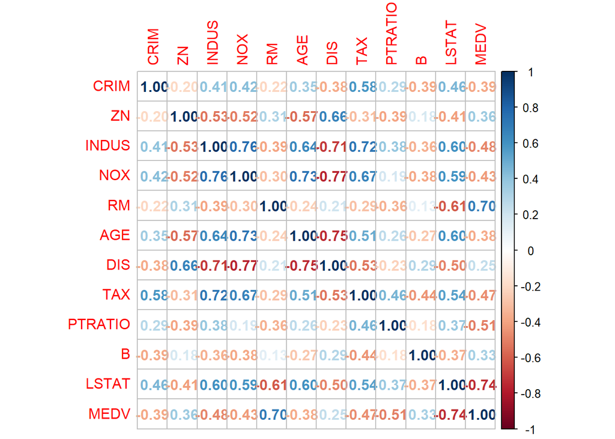

```r
library(corrplot)
corrplot(cor_matrix, method = "number")
```

#### DIS ve B değişkenleri MEDV ile düşük korelasyon katsayısına sahip oldukları için, bu degiskenlerin MEDV değişkenini yeterli seviyede açıklayamadığı anlaşılıyor. Pearson Korelasyon katsayılarına göre DIS ve B değişkenini veri setinden çıkarıp tekrar model kurulmalıdır.

## Seçilen Özelliklerle Modelin Kurulması

```r
train_pearson<-train[,c(1,2,3,4,5,6,8,9,11,12)]
test_pearson<-test[,c(1,2,3,4,5,6,8,9,11,12)]

lineer_model_pearson<-lm(MEDV~., data=train_pearson)

summary(lineer_model_pearson)
```

```
##
## Call:
## lm(formula = MEDV ~ ., data = train_pearson)
##
## Residuals:
##      Min       1Q   Median       3Q      Max
## -10.6148  -3.2152  -0.6998   1.8567  28.2160
##
## Coefficients:
##               Estimate Std. Error t value Pr(>|t|)
## (Intercept) 21.6084631  5.4596837   3.958 9.07e-05 ***
## CRIM        -0.0500526  0.0362733  -1.380    0.168
## ZN           0.0047260  0.0158464   0.298    0.766
## INDUS        0.0387797  0.0758950   0.511    0.610
## NOX         -5.3992209  4.6760770  -1.155    0.249
## RM           4.1030648  0.5156534   7.957 2.17e-14 ***
## AGE          0.0363714  0.0159359   2.282    0.023 *
## TAX          0.0004065  0.0030133   0.135    0.893
## PTRATIO     -0.9200685  0.1634152  -5.630 3.56e-08 ***
## LSTAT       -0.6256383  0.0620690 -10.080  < 2e-16 ***
## ---
## Signif. codes:  0 '***' 0.001 '**' 0.01 '*' 0.05 '.' 0.1 ' ' 1
##
## Residual standard error: 5.235 on 370 degrees of freedom
## Multiple R-squared:  0.6869, Adjusted R-squared:  0.6792
## F-statistic: 90.17 on 9 and 370 DF,  p-value: < 2.2e-16
```

## Katsayıların İncelenmesi

```r
coef(lineer_model_pearson)
```

```
##   (Intercept)          CRIM            ZN         INDUS           NOX
## 21.6084631120 -0.0500525805  0.0047260428  0.0387796968 -5.3992209032
##            RM           AGE           TAX       PTRATIO         LSTAT
##  4.1030647827  0.0363713923  0.0004065466 -0.9200685216 -0.6256382769
```

#### DIS ve B değişkenlerini veri setinden çıkarıp model kurulduğunda anlamsız değişkenlerin sayısı arttı. Bunun nedeni, DIS ve B değişkenlerinin MEDV değişkenini açıklamada önemli bilgiler içeriyor olması olabilir. DIS ve B değişkenlerinin veri setinden çıkarılması, kalan değişkenler arasındaki multicolinearity gibi problemlerin artmasına sebep olmuş olabilir. Bu durumlar varsayımlar üzerinden kontrol edilebilir.

## Normallik

```r
library(olsrr)
n<-nrow(train_pearson)
ols_test_normality(lineer_model_pearson)
```

```
## -----------------------------------------------
##        Test             Statistic       pvalue
## -----------------------------------------------
## Shapiro-Wilk              0.8622         0.0000
## Kolmogorov-Smirnov        0.137          0.0000
## Cramer-von Mises         33.4647         0.0000
## Anderson-Darling          11.083         0.0000
## -----------------------------------------------
```

#### n=380>50 olduğu için Kolmogrov-Smirnov sonucuna bakılmalıdır. p<0.05 olduğu için “H0: Artıklar normal dağılmaktadır” hipotezi reddedilir. Bu durumu grafik üzerinden kontrol etmek istersek:

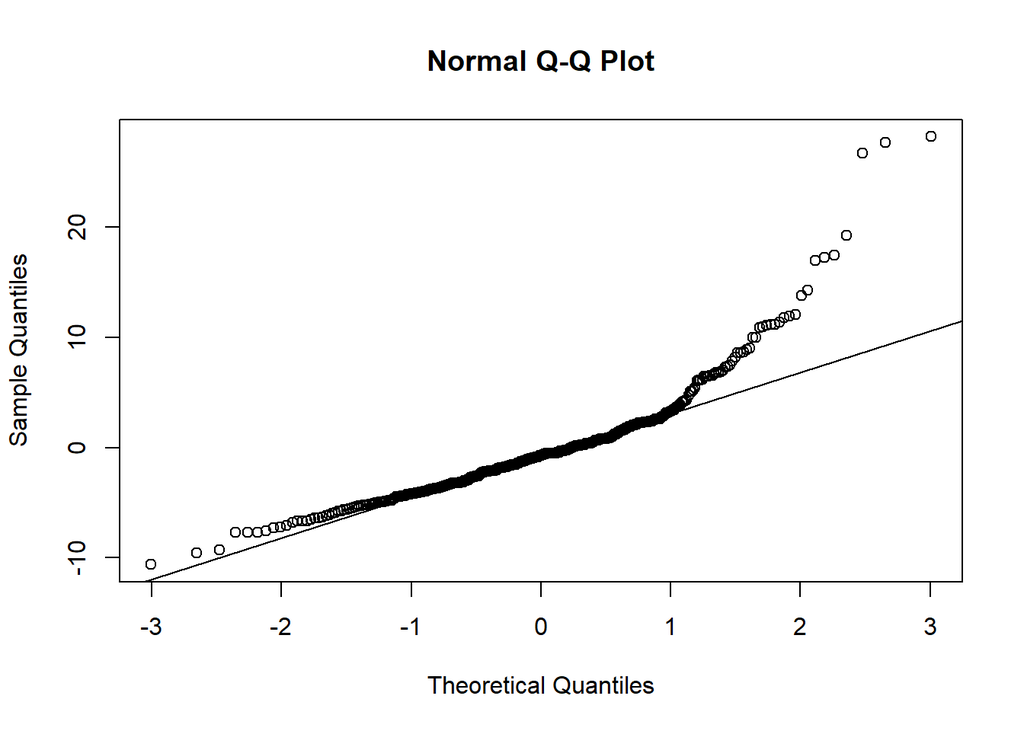

```r
qqnorm(residuals(lineer_model_pearson))
qqline(residuals(lineer_model_pearson))
```

#### Grafik, test sonucunu doğruluyor. Artıklar normal dağılmamaktadır.

## Değişken Varyanslılık

```r
library(lmtest)
bptest(lineer_model_pearson)
```

```
##
##  studentized Breusch-Pagan test
##
## data:  lineer_model_pearson
## BP = 30.632, df = 9, p-value = 0.0003423
```

#### p<0.05 olduğu için “H0: Değişken varyanslılık problemi yoktur” hipotezi reddedilir. Değişken varyans problemi vardır.

## Aykırı Değer

```r
library(olsrr)
ols_test_outlier(lineer_model_pearson)
```

```
##     studentized_residual unadjusted_p_val bonferroni_p_val
## 372             5.342427     1.608324e-07     6.111632e-05
## 373             5.676824     2.781206e-08     1.056858e-05
## 369             5.716322     2.248057e-08     8.542616e-06
```

#### unadjusted_p_value değerine ve bonferroni_p_value değerine göre veri setinde 3 tane outlier vardır.

## Multicolinearity

```r
library(car)
vifs<-vif(lineer_model_pearson)
which(vifs>10)
```

```
## named integer(0)
```

#### 10’dan büyük vif değeri olmadığı için multicolinearity problemi yoktur.

#### Normallik, Değişken varyans, Outlier varsayımları sağlanmıyor, Multicolinearity varsayımı sağlanıyor.

## Tahminlerin Elde Edilmesi

```r
set.seed(123)
tahmin_pearson<-predict(lineer_model_pearson, test_pearson)
```

## R2

```r
library(caret)
R2_Pearson<-R2(tahmin_pearson, test_pearson$MEDV)
R2_Pearson
```

```
## [1] 0.6801993
```

#### Model bağımlı değişkendeki toplam değişimin %68.01’ini bağımsız değişkenlerdeki değişimle açıklayabilmiştir. Modelin açıklama gücü, veri setinden çıkarılan değişkenler sonrasında düşmüştür. Buradan, DIS ve B değişkenlerinin MEDV değişkenini açıklamada katkı sağladığı anlaşılıyor.

## RMSE

```r
RMSE_Pearson<-RMSE(tahmin_pearson, test_pearson$MEDV)
RMSE_Pearson
```

```
## [1] 5.136899
```

## MAE

```r
MAE_Pearson<-MAE(tahmin_pearson, test_pearson$MEDV)
MAE_Pearson
```

```
## [1] 3.833224
```

#### RMSE ve MAE değerleri yükselmiştir. Bu kötü bir durumdur. Model daha kötü tahmin üretiyor.

## ÖZET TABLO

```r
Model<-c("Lineer Regression","Ridge","Lasso","Elasticnet","Pearson Korelasyon")
R2<-c(R2_lineer,R2_Ridge,R2_Lasso,R2_Elasticnet,R2_Pearson)
RMSE<-c(RMSE_lineer,RMSE_Ridge,RMSE_Lasso, RMSE_Elasticnet, RMSE_Pearson)
MAE<-c(MAE_lineer,MAE_Ridge, MAE_Lasso, MAE_Elasticnet, MAE_Pearson)
Degisken_sayisi<-c(12,12,10,10,10)
tablo<-data.frame(Model=Model,R2=R2, RMSE=RMSE, MAE=MAE,Degisken_Sayisi=Degisken_sayisi)

tablo
```

```
##                Model        R2     RMSE      MAE Degisken_Sayisi
## 1  Lineer Regression 0.7077899 4.906913 3.671364              12
## 2              Ridge 0.7124708 4.869217 3.626856              12
## 3              Lasso 0.7090676 4.896690 3.655581              10
## 4         Elasticnet 0.7098596 4.890439 3.649988              10
## 5 Pearson Korelasyon 0.6801993 5.136899 3.833224              10
```

#### Tüm metrikler ve test sonuçları değerlendirildiğinde; tüm değişkenlerle kurulan lineer regresyon modeli, Ridge, Lasso, Elasticnet modellerinin performansları neredeyse aynı. Pearson Korelasyon’a göre seçilen özelliklerle kurulan modelde performans biraz düştü. Elasticnet sonucunda daha az değişken kullanılarak yüksek model performansı sağlandığı için optimum model olarak Elasticnet sonucunda kurulan model seçilmelidir. Fakat bu modelin performansı da yeterli seviyede değildir. Bunun nedeni varsayımların sağlanmaması, yetersiz değişken sayısı veya yetersiz gözlem sayısı olabilir.

#### Özellik seçimi sonrasında modelin performansı artmadığı için, modele yeni önemli özellikler eklenebilir.

#### Kurulan modellerdeki varsayımların sağlanmaması durumu çözülüp modelin performası tekrardan ölçülebilir.